# Protein Differential Abundance Analysis

2024-06-19

As in a regular R script in RStudio, a single line of code can be run with Command-Enter (Mac OS) or Ctrl-Enter (Windows). Whole chunks of code can be run with Command(/Ctrl) + Shift + Enter **or** by clicking the green “>” button in the top-right corner of the chunk. Alternatively, these options can also be implemented by selecting lines of code and choosing the desired option from the drop-down menu in the “Run” tab, in the top-right corner of the of Source section of RStudio.

This workflow will import the dataset, perform preprocessing and differential abundance analysis. First, a normal or normal-like distribution is assumed and a t-test is performed. Proteins are filtered based on an FDR-adjusted p-value threshold (< 0.05) and a log2 fold change threshold (> 1). Then Linear and Nonlinear Mixed Effects Models (LNMM) approach is taken to model the data and extract fold change information and the corresponding p-values. Initial results are reported and each model is evaluated by running diagnostics and comparing the residuals, or the difference between the predicted value and the actual value (i.e. the ‘error’ in the predicted value).

Here is the workflow outline:

1. Aggregation: Mean log2 intensity for each protein in each condition (Control and Stress) is calculated across replicates.
2. Filtering: The data is separated into control_data and stress_data for easier manipulation.
3. Differential Analysis:
   - T-test: For each protein, a t-test is performed to compare the mean log2 intensities between Stress and Control conditions.
   - Linear and Nonlinear Mixed Effects Models: A more statistically robust approach is taken to account for deviations from normality.
4. Multiple Testing Correction: p-values are adjusted using the FDR method to control the false discovery rate.
5. Model Diagnostics: Each model used is evaluated to assess the validity of the extracted coefficients like log2 fold changes.

While initially, using a t-test to determine proteins undergoing changes in abundance is useful, given deviations from normality often seen in proteomics experiments, the structure of the data and the objectives of the analysis, using LNMM for differential abundance analysis seems more appropriate. The `nlme` package allows for flexible modeling of both fixed effects (e.g., experimental conditions like Time and CellType) and random effects (e.g., Batch/Replicate). This flexibility can be beneficial for capturing the hierarchical structure of the data and adjusting for nested experimental designs.

To comment or uncomment a series of lines, highlight the lines and use Command(/Ctrl) + Shift + C.

R packages `preprocessCore`, `ggplot2`, `dplyr`, `reshape2`, `stats`, `multcomp`, `EnhancedVolcano` as well as `nlme` are required for this workflow.They can be installed using the following commands:

```r
# install.packages("preprocessCore")
# install.packages("ggplot2")
# install.packages("dplyr")
# install.packages("reshape2")
# install.packages("stats")
# install.packages("multcomp")
# install.packages("EnhancedVolcano")
# install.packages("nlme")

# If install.packages("packagename") command fails in newer versions of R uncomment and run the commands:
# if (!require("BiocManager", quietly = TRUE))
#    install.packages("BiocManager")
# BiocManager::install("packagename")
```

Once installed, load the packages.

```r
# Load required libraries
library(preprocessCore)   # For data preprocessing
library(ggplot2)          # For data visualization
library(dplyr)            # For data manipulation
library(reshape2)         # For restructuring and aggregating data
library(stats)            # For statistical analysis
library(multcomp)         # For multiple comparisons of k groups in general linear models
library(EnhancedVolcano)  # For visualization of differential analysis
library(nlme)             # For differential analysis using Linear and Nonlinear Mixed Effects Models (LNMM)
# Load the dataset
data <- read.csv("~/Desktop/proteomicsSampleData.csv")

# Display the structure of the dataset
str(data)
```

```
## 'data.frame':    17282 obs. of  8 variables:
##  $ Gene         : chr  "CTDSPL" "CTDSPL" "CTDSPL" "CTDSPL" ...
##  $ ProteinID    : chr  "sp|O15194|CTDSL_HUMAN" "sp|O15194|CTDSL_HUMAN" "sp|O15194|CTDSL_HUMAN" "sp|O15194|CTDSL_HUMAN" ...
##  $ Peptide      : chr  "K.ASQCNVSLK.K" "K.ASQCNVSLK.K" "K.ASQCNVSLK.K" "K.ASQCNVSLK.K" ...
##  $ Batch        : chr  "HAQ1" "HAQ1" "HAQ1" "HAQ1" ...
##  $ Time         : int  20 20 25 25 29 33 33 37 46 50 ...
##  $ CellType     : chr  "Control" "Stress" "Control" "Stress" ...
##  $ Replicate    : int  1 1 1 1 1 1 1 1 1 1 ...
##  $ Log_Intensity: num  12.5 12.9 13.4 13.1 12.4 ...
```

```r
# Sort the data by CellType, Batch, and Replicate
data <- data[order(data$CellType, data$Batch, data$Replicate), ]

# Convert Log_Intensity column to a matrix with one column
log_intensity_matrix <- as.matrix(data$Log_Intensity)

# Normalize the matrix using preprocessCore
normalized_matrix <- normalize.quantiles(log_intensity_matrix)

# Convert the normalized matrix back to a vector
normalized_log_intensity <- as.vector(normalized_matrix)

# Update the Log_Intensity column with the normalized values
data$Log_Intensity <- normalized_log_intensity

# Verify the changes
head(data)
```

```
##      Gene             ProteinID          Peptide Batch Time CellType Replicate
## 1  CTDSPL sp|O15194|CTDSL_HUMAN    K.ASQCNVSLK.K  HAQ1   20  Control         1
## 3  CTDSPL sp|O15194|CTDSL_HUMAN    K.ASQCNVSLK.K  HAQ1   25  Control         1
## 6  CTDSPL sp|O15194|CTDSL_HUMAN    K.ASQCNVSLK.K  HAQ1   33  Control         1
## 40 CTDSPL sp|O15194|CTDSL_HUMAN K.EDEGRLPGAGEK.A  HAQ1   20  Control         1
## 42 CTDSPL sp|O15194|CTDSL_HUMAN K.EDEGRLPGAGEK.A  HAQ1   25  Control         1
## 45 CTDSPL sp|O15194|CTDSL_HUMAN K.EDEGRLPGAGEK.A  HAQ1   33  Control         1
##    Log_Intensity
## 1       12.52650
## 3       13.35365
## 6       13.12534
## 40      15.56973
## 42      15.72280
## 45      15.66517
```

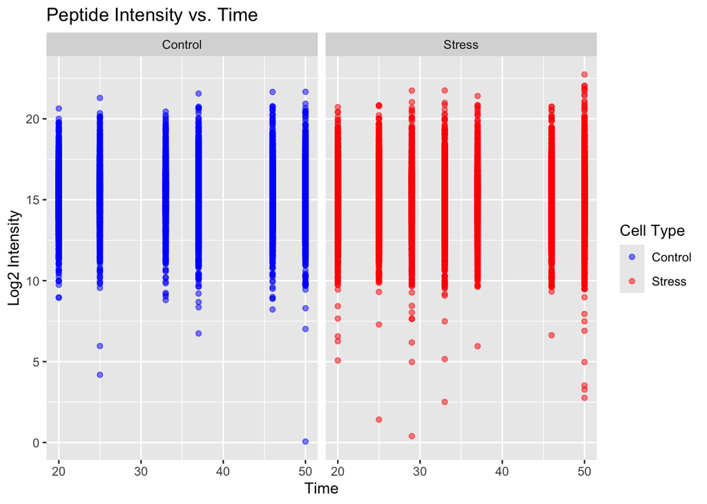

```r
# Visualization: Create a plot of log2 intensity vs. time, colored by CellType
ggplot(data, aes(x = Time, y = Log_Intensity, color = CellType)) +
  geom_point(alpha = 0.5) +  # Set transparency for better visualization of overlapping points
  scale_color_manual(values = c("blue", "red")) +
  labs(x = "Time", y = "Log2 Intensity", color = "Cell Type") +
  ggtitle("Peptide Intensity vs. Time") +
  facet_wrap(~CellType)
```

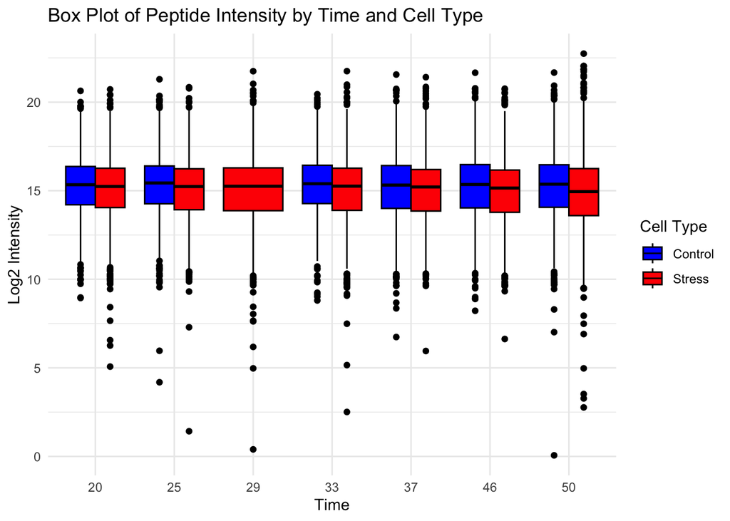

```r
# Visualization: Create a box plot of peptide intensity by Time and Cell Type
ggplot(data, aes(x = factor(Time), y = Log_Intensity, fill = CellType)) +
  geom_boxplot(position = "dodge", color = "black") +
  scale_fill_manual(values = c("blue", "red")) +
  labs(x = "Time", y = "Log2 Intensity", fill = "Cell Type") +
  ggtitle("Box Plot of Peptide Intensity by Time and Cell Type") +
  theme_minimal()
```

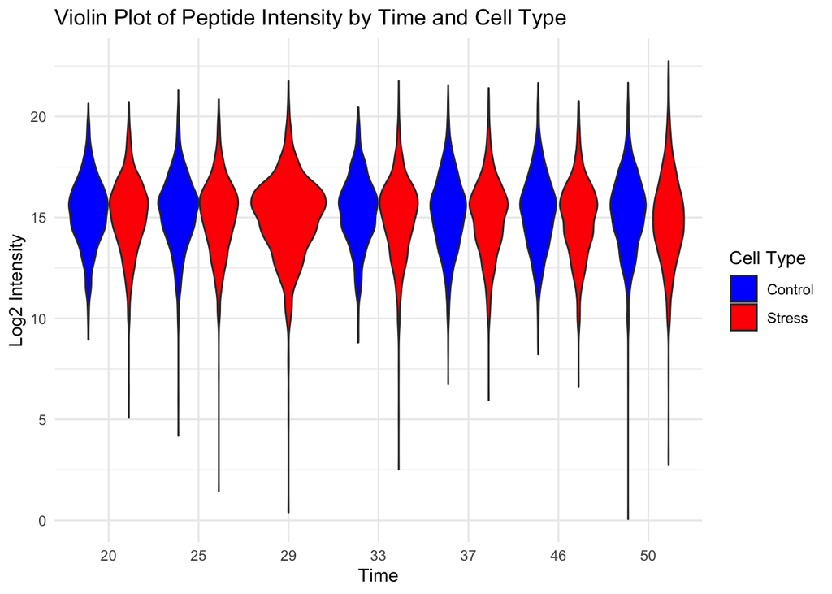

```r
# Visualization: Create a violin plot of peptide intensity by Time and Cell Type
ggplot(data, aes(x = factor(Time), y = Log_Intensity, fill = CellType)) +
  geom_violin(position = "dodge") +
  scale_fill_manual(values = c("blue", "red")) +
  labs(x = "Time", y = "Log2 Intensity", fill = "Cell Type") +
  ggtitle("Violin Plot of Peptide Intensity by Time and Cell Type") +
  theme_minimal()
```

```r
# Summarization: Calculate mean log2 intensity for each protein
protein_summary <- data %>%
  group_by(Gene, Time, CellType) %>%
  summarize(mean_log2_intensity = mean(Log_Intensity))
# Filtering: Identify proteins with > 1 fold changes in abundance
filtered_proteins <- protein_summary %>%
  group_by(Gene, CellType) %>%
  summarize(max_intensity_change = max(mean_log2_intensity) - min(mean_log2_intensity)) %>%
  filter(max_intensity_change > 1)  # Set threshold based on desired fold change or significance level
head(filtered_proteins)
```

```
## # A tibble: 6 × 3
## # Groups:   Gene [5]
##   Gene     CellType max_intensity_change
##   <chr>    <chr>                   <dbl>
## 1 ""       Control                  1.14
## 2 ""       Stress                   1.91
## 3 "AIP"    Control                  1.46
## 4 "ANKRD9" Stress                   1.94
## 5 "BRWD1"  Stress                   1.16
## 6 "CACYBP" Stress                   1.30
```

```r
# Additional steps for sorting the data
sorted_data <- arrange(data, CellType, Batch, Replicate)
```

```r
# Load necessary libraries again
library(dplyr)
library(reshape2)
library(multcomp)
library(stats)

# Step 1: Aggregate log2 peptide intensities at the protein level
protein_data <- sorted_data %>%
  group_by(Gene, ProteinID, CellType, Time, Replicate) %>%
  summarize(mean_Log_Intensity = mean(Log_Intensity, na.rm = TRUE))
```

```
## You can override using the `.groups` argument.
```

```r
# Step 2: Prepare data for t-tests
# Filter data for Control and Stress
control_data <- protein_data %>% filter(CellType == "Control")
stress_data <- protein_data %>% filter(CellType == "Stress")

# Step 3: Perform t-tests for each protein
results <- protein_data %>%
  group_by(Gene, ProteinID) %>%
  summarize(
    log2_fold_change = mean(mean_Log_Intensity[CellType == "Stress"], na.rm = TRUE) -
                       mean(mean_Log_Intensity[CellType == "Control"], na.rm = TRUE),
    p_value = t.test(
      mean_Log_Intensity[CellType == "Stress"],
      mean_Log_Intensity[CellType == "Control"]
    )$p.value
  ) %>%
  ungroup()
# Step 4: Adjust p-values using the FDR method
results <- results %>%
  mutate(FDR_adj_p_value = p.adjust(p_value, method = "fdr"))

# Step 5: Filter significant results based on FDR-adjusted p-value and log2 fold change threshold
significant_proteins <- results %>%
  filter(FDR_adj_p_value < 0.05 & abs(log2_fold_change) > 1)

# Print all proteins
# print(results)

# Print significant proteins
print(significant_proteins)
```

```
## # A tibble: 9 × 5
##   Gene         ProteinID                log2_fold_change p_value FDR_adj_p_value
##   <chr>        <chr>                               <dbl>   <dbl>           <dbl>
## 1 ""           tr|A8K6K9|A8K6K9_HUMAN              -2.04 2.92e-7     0.00000487
## 2 "CACYBP"     tr|A0A024R904|A0A024R90…            -1.08 3.53e-4     0.00176
## 3 "COA7"       sp|Q96BR5|COA7_HUMAN                -1.08 1.76e-8     0.000000880
## 4 "FGL2"       tr|A4D1B8|A4D1B8_HUMAN              -3.68 7.76e-4     0.00353
## 5 "GOLPH3L"    sp|Q9H4A5|GLP3L_HUMAN               -1.01 2.80e-4     0.00155
## 6 "LRIG3"      sp|Q6UXM1|LRIG3_HUMAN               -1.33 2.76e-7     0.00000487
## 7 "NRGN"       tr|A0A024R3M7|A0A024R3M…            -1.42 4.83e-3     0.0134
## 8 "PMF1-BGLAP" tr|U3KQ54|U3KQ54_HUMAN              -1.01 4.47e-3     0.0134
## 9 "POLR3H"     tr|A0A024R1P3|A0A024R1P…            -1.18 6.08e-5     0.000457
```

```r
# Save results to CSV
# write.csv(results, 'results_diff_t-test.csv', row.names = FALSE)
# write.csv(significant_proteins, 'results_sig_FC_t-test.csv', row.names = FALSE)
```

There are 9 proteins showing negative fold change when comparing Stress vs Control conditions that pass the FDR-adjusted p-value threshold (< 0.05) and a log2 fold change threshold ( > 1). Negative fold change indicates that these proteins underwent a decrease in abundance going from the control to the stress condition.

Let’s visualize the results using a volcano plot and `EnhancedVolcano` package.

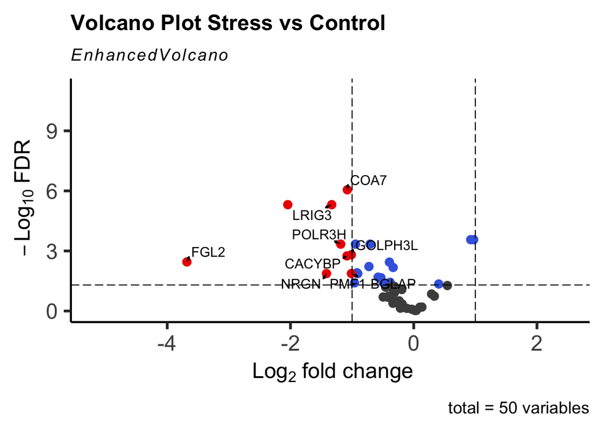

```r
# Load the EnhancedVolcano library
library(EnhancedVolcano)

# Create the volcano plot
EnhancedVolcano(
  results,
  lab = results$Gene,  # Labels for the points
  x = 'log2_fold_change',  # Log2 fold changes
  y = 'FDR_adj_p_value',  # FDR-adjusted p-values
  title = 'Volcano Plot Stress vs Control',
  xlab = bquote(~Log[2]~ 'fold change'),
  ylab = bquote(~-Log[10]~ 'FDR'),
  pCutoff = 0.05,  # P-value cutoff
  FCcutoff = 1,  # Fold change cutoff
  pointSize = 3.0,
  labSize = 4.0,
  col = c('grey30', 'forestgreen', 'royalblue', 'red2'),
  colAlpha = 1,
  legendLabels = NULL,  # Remove legend
  legendPos = "none",   # Remove legend position
  legendLabSize = 0,     # Remove legend label size
  drawConnectors = TRUE,
  widthConnectors = 0.5,
  colConnectors = 'black',
  gridlines.major = FALSE,
  gridlines.minor = FALSE
)
```

Next, let’s perform some diagnostic tests on our model to see how the residuals are distributed. If they appear to be normally distributed based on the Q-Q plots and Shapiro-Wilk test, the assumptions of the t-test would be reasonably satisfied. If not, we might need to consider using non-parametric tests or transformations to better meet the assumptions of the t-test.

```r
# Load necessary libraries
library(dplyr)
library(reshape2)
library(ggplot2)

# Step 1: Aggregate log2 peptide intensities at the protein level
protein_data <- sorted_data %>%
  group_by(Gene, ProteinID, CellType, Time, Replicate) %>%
  summarize(mean_Log_Intensity = mean(Log_Intensity, na.rm = TRUE))
```

```
## You can override using the `.groups` argument.
```

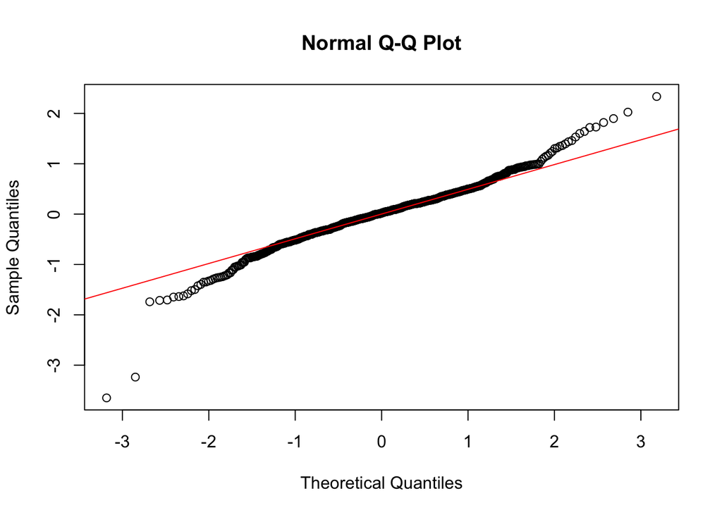

```r
# Prepare data for residuals calculation
control_data <- protein_data %>% filter(CellType == "Control")
stress_data <- protein_data %>% filter(CellType == "Stress")

# Calculate residuals for each protein
residuals_data <- protein_data %>%
  group_by(Gene, ProteinID) %>%
  mutate(
    mean_control_intensity = mean(mean_Log_Intensity[CellType == "Control"], na.rm = TRUE),
    residuals = mean_Log_Intensity - mean_control_intensity
  ) %>%
  ungroup()

# Step 2: Generate Q-Q plots and perform Shapiro-Wilk test for normality on residuals
residuals_control <- residuals_data %>% filter(CellType == "Control") %>% pull(residuals)
residuals_stress <- residuals_data %>% filter(CellType == "Stress") %>% pull(residuals)

# Generate Q-Q plot for Control residuals
qqnorm(residuals_control)
qqline(residuals_control, col = "red")
```

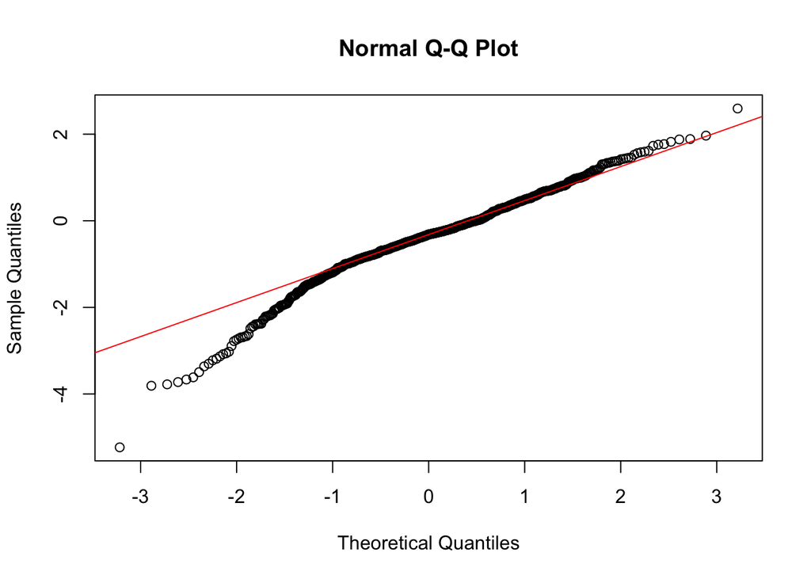

```r
# Generate Q-Q plot for Stress residuals
qqnorm(residuals_stress)
qqline(residuals_stress, col = "red")
```

```r
# Perform Shapiro-Wilk test for normality on residuals
shapiro_control <- shapiro.test(residuals_control)
shapiro_stress <- shapiro.test(residuals_stress)

# Print Shapiro-Wilk test results
print(shapiro_control)
```

```
##
##  Shapiro-Wilk normality test
##
## data:  residuals_control
## W = 0.96377, p-value = 5.541e-12
```

```r
print(shapiro_stress)
```

```
##
##  Shapiro-Wilk normality test
##
## data:  residuals_stress
## W = 0.96774, p-value = 4.854e-12
```

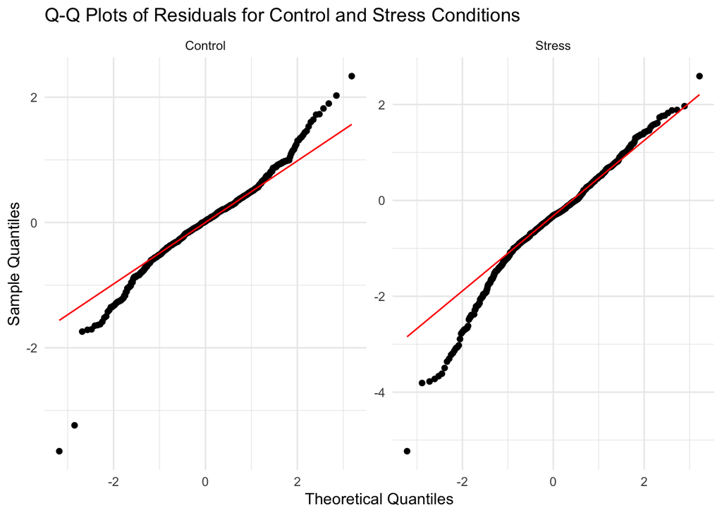

```r
# Alternatively, use ggplot2 for Q-Q plots
ggplot(residuals_data, aes(sample = residuals)) +
  stat_qq() +
  stat_qq_line(colour = "red") +
  facet_wrap(~ CellType, scales = "free") +
  theme_minimal() +
  labs(title = "Q-Q Plots of Residuals for Control and Stress Conditions",
       x = "Theoretical Quantiles",
       y = "Sample Quantiles")
```

In the context of the Shapiro-Wilk test, the null hypothesis is that the data is normally distributed. The alternative hypothesis is that the data is not normally distributed. If the p-value is greater than 0.05, we fail to reject the null hypothesis, suggesting that the data does not significantly deviate from normality (i.e., it is reasonable to assume the data is normally distributed). If the p-value is less than 0.05, we reject the null hypothesis, indicating that the data significantly deviates from normality.

Our W Values: Around 0.96 for both control and stress residuals. Our P-Values: Very small (5.541e-12 for control and 4.854e-12 for stress).

Despite the W values being relatively close to 1, the very small p-values suggest that the deviations from normality are statistically significant. This means that while the data might appear somewhat normally distributed based on the W statistic, the statistical test strongly suggests that there is some deviation from a perfect normal distribution.

Let’s use a non-parametric tests that do not assume normality, such as the Wilcoxon rank-sum test to determine the significance of observed fold changes.

```r
# Perform Wilcoxon rank-sum test for each protein
results <- protein_data %>%
  group_by(Gene, ProteinID) %>%
  summarize(
    log2_fold_change = mean(mean_Log_Intensity[CellType == "Stress"], na.rm = TRUE) -
                       mean(mean_Log_Intensity[CellType == "Control"], na.rm = TRUE),
    p_value = wilcox.test(
      mean_Log_Intensity[CellType == "Stress"],
      mean_Log_Intensity[CellType == "Control"]
    )$p.value
  ) %>%
  ungroup()
# Adjust p-values using the FDR method
results <- results %>%
  mutate(fdr_adjusted_p_value = p.adjust(p_value, method = "fdr"))

# Filter significant results based on FDR-adjusted p-value and log2 fold change threshold
significant_proteins <- results %>%
  filter(fdr_adjusted_p_value < 0.05 & abs(log2_fold_change) > 1)

# Print significant proteins
print(significant_proteins)
```

```
## # A tibble: 9 × 5
##   Gene         ProteinID           log2_fold_change p_value fdr_adjusted_p_value
##   <chr>        <chr>                          <dbl>   <dbl>                <dbl>
## 1 ""           tr|A8K6K9|A8K6K9_H…            -2.04 2.24e-6           0.0000374
## 2 "CACYBP"     tr|A0A024R904|A0A0…            -1.08 3.33e-5           0.000333
## 3 "COA7"       sp|Q96BR5|COA7_HUM…            -1.08 2.19e-8           0.00000110
## 4 "FGL2"       tr|A4D1B8|A4D1B8_H…            -3.68 1.67e-2           0.0379
## 5 "GOLPH3L"    sp|Q9H4A5|GLP3L_HU…            -1.01 1.45e-3           0.00482
## 6 "LRIG3"      sp|Q6UXM1|LRIG3_HU…            -1.33 5.98e-7           0.0000150
## 7 "NRGN"       tr|A0A024R3M7|A0A0…            -1.42 1.52e-2           0.0362
## 8 "PMF1-BGLAP" tr|U3KQ54|U3KQ54_H…            -1.01 4.63e-3           0.0129
## 9 "POLR3H"     tr|A0A024R1P3|A0A0…            -1.18 6.24e-5           0.000520
```

Let’s visualize the results using a volcano plot as we did following differential analysis using a t-test.

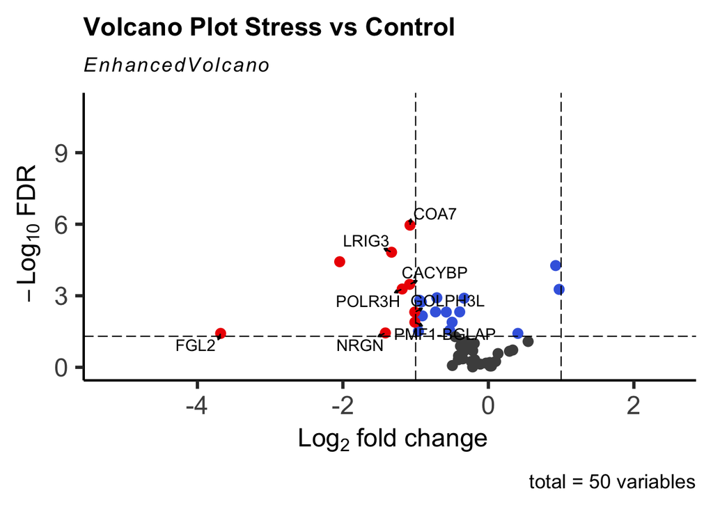

```r
# Create the volcano plot
EnhancedVolcano(
  results,
  lab = results$Gene,  # Labels for the points
  x = 'log2_fold_change',  # Log2 fold changes
  y = 'fdr_adjusted_p_value',  # FDR-adjusted p-values
  title = 'Volcano Plot Stress vs Control',
  xlab = bquote(~Log[2]~ 'fold change'),
  ylab = bquote(~-Log[10]~ 'FDR'),
  pCutoff = 0.05,  # P-value cutoff
  FCcutoff = 1,  # Fold change cutoff
  pointSize = 3.0,
  labSize = 4.0,
  col = c('grey30', 'forestgreen', 'royalblue', 'red2'),
  colAlpha = 1,
  legendLabels = NULL,  # Remove legend
  legendPos = "none",   # Remove legend position
  legendLabSize = 0,     # Remove legend label size
  drawConnectors = TRUE,
  widthConnectors = 0.5,
  colConnectors = 'black',
  gridlines.major = FALSE,
  gridlines.minor = FALSE
)
```

This is more or less what we saw using the parametric model fitting and the t-test statistic determination.

```r
# Load required library
library(multcomp)
library(nlme)

# Convert CellType to factor
data$CellType <- as.factor(data$CellType)

# Filter data for the selected proteins
selected_genes <- c("LRIG3", "POLR3H", "FGL2", "CACYBP", "NRGN", "COA7")
filtered_data <- data[data$Gene %in% selected_genes, ]

# Calculate log fold change
fold_change <- tapply(filtered_data$Log_Intensity, filtered_data$Gene, function(x) max(x) - min(x))

# Perform statistical tests
results <- sapply(selected_genes, function(gene) {
  # Subset data for the current gene
  gene_data <- filtered_data[filtered_data$Gene == gene, ]

  # Fit linear mixed model
  model <- lme(Log_Intensity ~ CellType, random = ~1 | Batch/Replicate, data = gene_data)

  # Perform hypothesis tests for CellType
  test_result <- glht(model, linfct = mcp(CellType = "Tukey"))

  # Extract the p-value for the contrast of interest (Stress vs Control)
  p_value <- summary(test_result)$test$pvalues[2]

  return(p_value)
})

# Adjust p-values using FDR correction
adjusted_p_values <- p.adjust(results, method = "fdr")

# Combine fold change and adjusted p-values into a data frame
results_df <- data.frame(Gene = names(results), Log_Fold_Change = fold_change, P_Value = adjusted_p_values, row.names = NULL)

# Print results
print(results_df)
```

```
##     Gene Log_Fold_Change P_Value
## 1  LRIG3        9.907158      NA
## 2 POLR3H        8.241306      NA
## 3   FGL2        8.704729      NA
## 4 CACYBP       15.020885      NA
## 5   NRGN       11.494128      NA
## 6   COA7        4.367064      NA
```

- Fit separate linear mixed models for each time point.
- Extract coefficients and p-values for the comparison between Stress vs Control conditions at each time point.
- Calculate log-fold changes based on the coefficients.
- Adjust p-values for multiple testing if necessary.

```r
library(dplyr)
library(nlme)

# Create an empty data frame to store results
results_list <- list()

# Fit separate linear mixed models for each time point except 29
for (time_point in setdiff(unique(data$Time), 29)) {
  # Subset the data for the current time point
  subset_data <- filter(data, Time == time_point)

  # Check if both levels of CellType are present
  if (all(levels(subset_data$CellType) %in% c("Control", "Stress"))) {
    # Fit the linear mixed model
    model <- lme(Log_Intensity ~ CellType, random = ~1 | Batch/Replicate, data = subset_data)

    # Extract coefficients and p-values
    coefficients <- fixef(model)
    summary_info <- summary(model)

    # Get p-value for CellTypeStress coefficient
    p_value <- summary_info$tTable["CellTypeStress", "p-value"]

    # Check if p_value is not NA
    if (!is.na(p_value)) {
      # Store results in a list
      results_list[[as.character(time_point)]] <- c(coefficients["CellTypeStress"], p_value)
    } else {
      print(paste("Skipping time point", time_point, "due to missing p-value for CellTypeStress"))
    }
  } else {
    # Print a message if one of the levels is missing
    print(paste("Skipping time point", time_point, "due to missing levels of CellType"))
  }
}

# Convert the results to a data frame
results_df <- do.call(rbind.data.frame, results_list)
colnames(results_df) <- c("Log_Fold_Change", "P_Value")

# Add the Time column
results_df$Time <- as.numeric(rownames(results_df))

# Print the results
print(results_df)
```

```
##   Log_Fold_Change     P_Value Time
## 1     -0.09423127 0.268183621    1
## 2     -0.15407185 0.080556413    2
## 3     -0.19207714 0.107203527    3
## 4     -0.19396584 0.016738558    4
## 5     -0.31670597 0.001365411    5
## 6     -0.33423467 0.002605024    6
```

```r
library(stats)
library(ggplot2)

# Join the results dataframe with the original data to obtain gene names
results_with_genes <- inner_join(results_df, data, by = "Time")

# Calculate FDR-adjusted p-values
results_with_genes <- results_with_genes %>%
mutate(FDR = p.adjust(p_value, method = "fdr"))

print(results_with_genes)
```

```
##  [1] Log_Fold_Change P_Value         Time            Gene
##  [5] ProteinID       Peptide         Batch           CellType
##  [9] Replicate       Log_Intensity   FDR
## <0 rows> (or 0-length row.names)
```

```r
# Create a volcano plot
# Define the limits for the x-axis and y-axis
x_limits <- c(-2, 2)  # Log2 fold change from -2 to 2
y_limits <- c(0, 20)  # -log10(FDR) from 0 to 20

# Volcano plot
volcano_plot <- ggplot(results_with_genes, aes(x = log_fold_changes, y = -log10(FDR), color = CellType)) +
  geom_point() +
  geom_hline(yintercept = -log10(0.05), linetype = "dashed", color = "red") +
  xlim(x_limits) +  # Set x-axis limits
  ylim(y_limits) +  # Set y-axis limits
  labs(x = "Log2 Fold Change (Stress vs Control)", y = "-log10(FDR-adjusted p-value)", color = "Cell Type", title = "Volcano Plot") +
  theme_minimal()

# Show the plot
# print(volcano_plot)
```

Further experimentation or validation by correlating protein abundance data with mRNA expression data by RNA-seq may be necessary to confirm these observations.

And last but not least, while using a linear mixed model approach for differential abundance analysis in proteomics experiments is well suited for complex multidimensional data, its appropriateness depends on several factors. Here are some considerations:

- Linearity: LMMs assume a linear relationship between the response variable and the predictor variables.
- Normality of Residuals: LMMs assume that the residuals (errors) are normally distributed. Violations of this assumption can affect the validity of statistical inference.
- Homogeneity of Variance: LMMs assume homogeneity of variance, meaning that the variance of the residuals is constant across all levels of the predictors. Heteroscedasticity can lead to biased parameter estimates and incorrect hypothesis testing.
- Independence of Observations: LMMs assume independence of observations within groups defined by the random effects.

Model Diagnostics: It’s essential to check the assumptions of the linear mixed model, such as normality, homoscedasticity, and independence of residuals. Residual diagnostics, such as residual plots and tests, can help evaluate whether these assumptions hold.

To test the assumptions of the linear mixed model, we can perform various diagnostic tests.

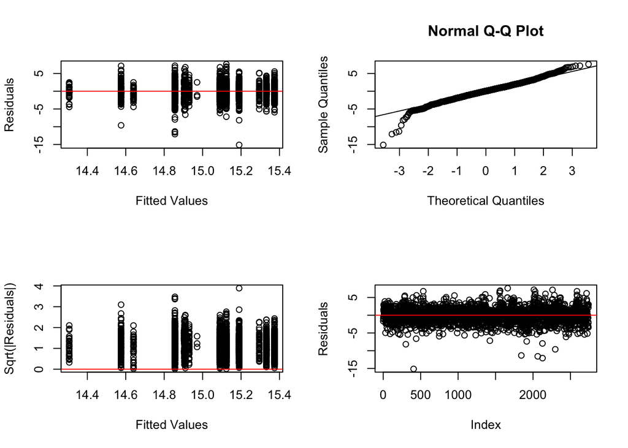

```r
# Fit the linear mixed effects model
model <- lme(Log_Intensity ~ CellType, random = ~1 | Batch/Replicate, data = subset_data)

# Extract residuals and fitted values
resid <- residuals(model)
fitted <- fitted(model)

# Diagnostic plots
par(mfrow = c(2, 2))  # Set up a 2x2 grid for multiple plots

# Residual vs. Fitted Values Plot
plot(fitted, resid, xlab = "Fitted Values", ylab = "Residuals")
abline(h = 0, col = "red")  # Add a red line at y = 0

# Normal Q-Q Plot
qqnorm(resid)
qqline(resid)

# Scale-Location Plot
plot(sqrt(abs(resid)) ~ fitted, xlab = "Fitted Values", ylab = "Sqrt(|Residuals|)")
abline(h = 0, col = "red")  # Add a red line at y = 0

# Residuals vs. Index Plot (for checking for autocorrelation)
index <- 1:length(resid)
plot(index, resid, xlab = "Index", ylab = "Residuals")
abline(h = 0, col = "red")  # Add a red line at y = 0
```

```r
# Reset the plotting layout
par(mfrow = c(1, 1))
```

The Q-Q plot suggests that the residuals are approximately normally distributed and that the assumption of normality for the residuals is met. However, the presence of a few outliers falling below the diagonal line in the -3 quantile could indicate some deviations from normality in the tails of the distribution.

While the Q-Q plot indicates that the residuals are normally distributed, the Residuals vs Fitted Values plot suggests potential non-linearity. The groups of overlapping points forming vertical lines could indicate some systematic patterns or structure in the residuals that are not captured by the linear mixed model.

In such cases, further investigation is warranted to understand the underlying reasons for the observed patterns in the residuals, to revisit experimental and data acquisition considerations, and to determine whether any model adjustments, transformations or alternative models are necessary to improve model fit and validity.